# Sly

Lieke Vlaar

30/04/2021

# Introduction

In this file the complete analysis workflow of count data of the tomato RNAseq experiment is shown.

## Goal

The goal of this experiment is to unravel the effect of solanoeclepin A on the plant. Solanoeclepin A is applied on tomato seedlings and roots and shoots are harvested separately. The set up of this experiment is summarized in this figure:

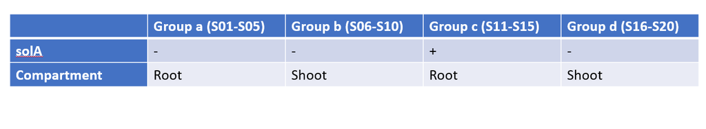

## Setup

Packages necessary:

- Checkpoint
- DESeq2
- dplyr
- tidyr
- tidyverse
- Biostrings
- biomaRt
- biomartr
- clusterProfiler
- tibble
- mixOmics
- vegan
- apeglm
- EnhancedVolcano
- patchwork
- GenomicFeatures

#PCA analysis

Plot PCA to see if samples with the same treatments cluster together.

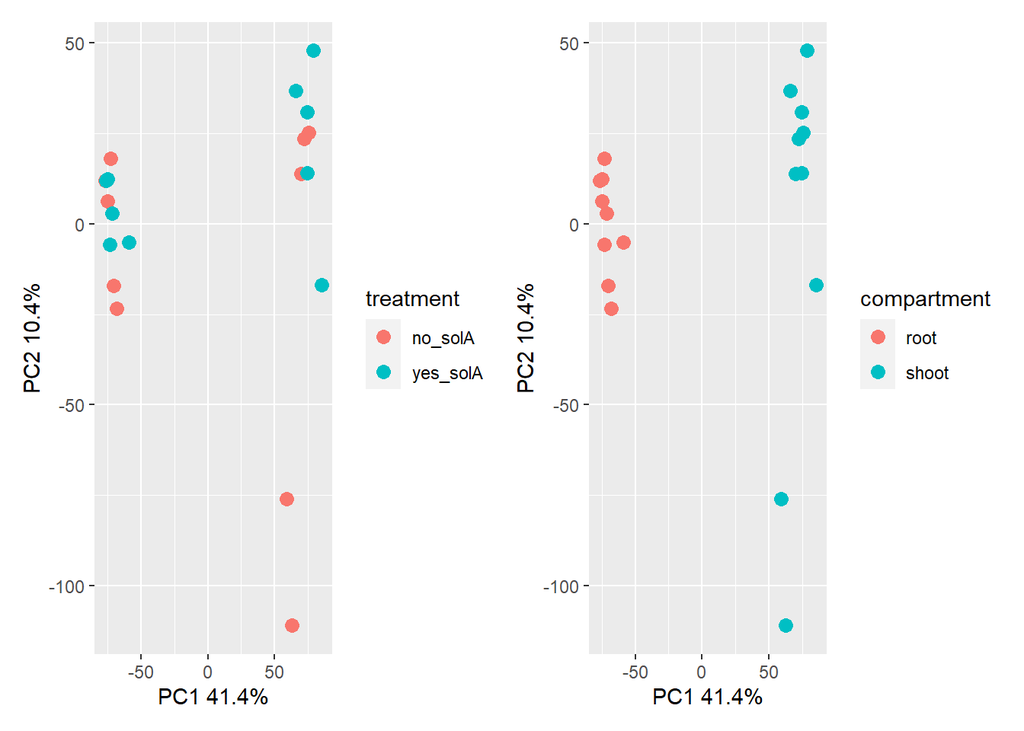

```r
source("Sly1/scripts/create_pca_plot.R")
p1 <- plot_pca(plantpart = c("root", "shoot"), pca_colour = "treatment")
p2 <- plot_pca(plantpart = c("root", "shoot"), pca_colour = "compartment")
p1 + p2
```

On PC1, the compartments cluster together. There is no clear clustering based on solA treatment. Let’s check PC3 and PC4.

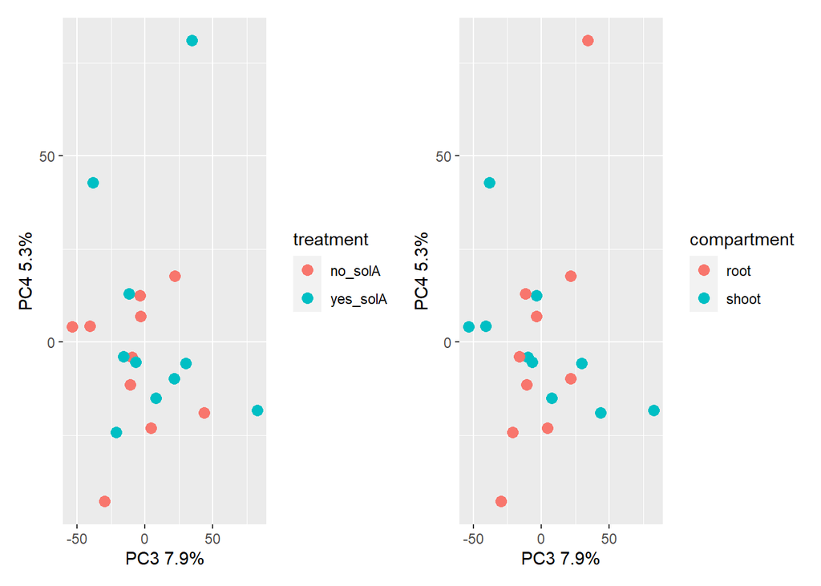

```r
p1 <- plot_pca(plantpart = c("root", "shoot"), pc_x_axis = "PC3", pc_y_axis = "PC4", pca_colour = "treatment")
p2 <- plot_pca(plantpart = c("root", "shoot"), pc_x_axis = "PC3", pc_y_axis = "PC4", pca_colour = "compartment")
p1 + p2
```

Also no good separation. Let’s plot the screeplot:

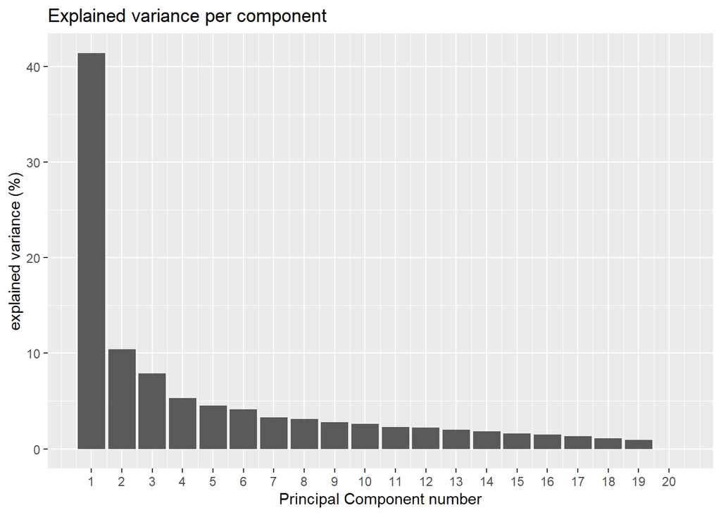

```r
source("Sly1/scripts/scree_plot.R")
plot_scree(comp = c("root","shoot"))
```

It would be more informative to look at the compartments individually.

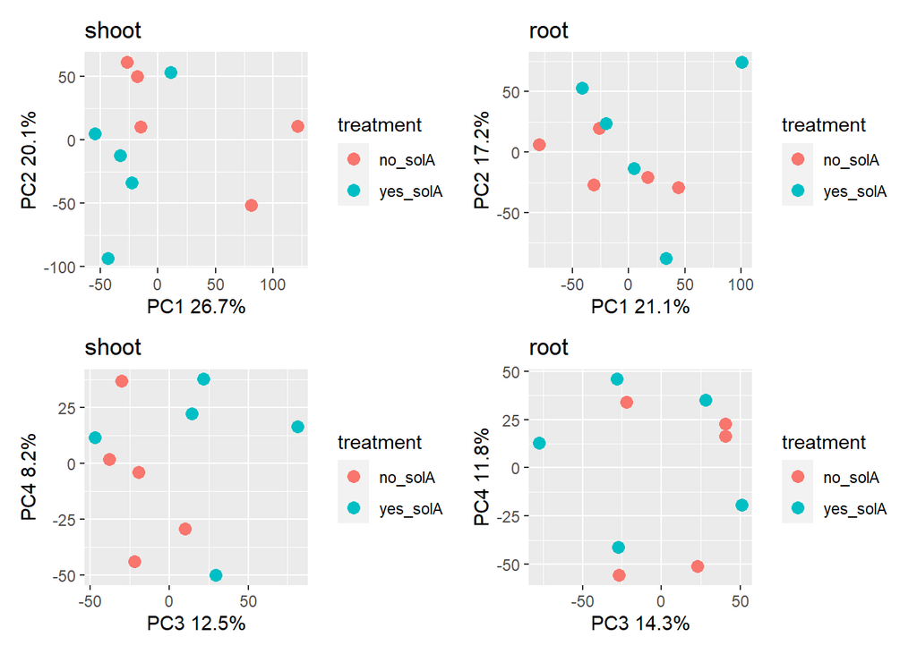

```r
p1 <- plot_pca(plantpart = c("shoot"), pc_x_axis = "PC1", pc_y_axis = "PC2", pca_colour = "treatment") + ggtitle("shoot")
p2 <- plot_pca(plantpart = c("root"), pc_x_axis = "PC1", pc_y_axis = "PC2", pca_colour = "treatment") + ggtitle("root")
p3 <- plot_pca(plantpart = c("shoot"), pc_x_axis = "PC3", pc_y_axis = "PC4", pca_colour = "treatment") +ggtitle("shoot")
p4 <- plot_pca(plantpart = c("root"), pc_x_axis = "PC3", pc_y_axis = "PC4", pca_colour = "treatment") + ggtitle("root")
(p1 + p2) / (p3 + p4)
```

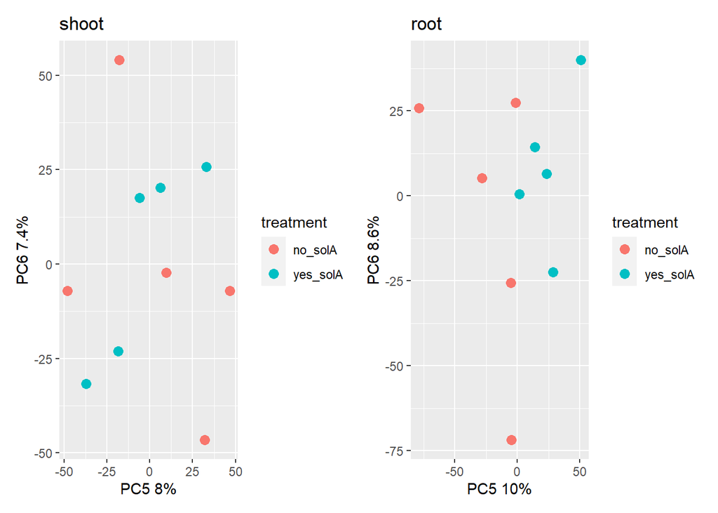

```r
p1 <- plot_pca(plantpart = c("shoot"), pc_x_axis = "PC5", pc_y_axis = "PC6", pca_colour = "treatment") + ggtitle("shoot")
p2 <- plot_pca(plantpart = c("root"), pc_x_axis = "PC5", pc_y_axis = "PC6", pca_colour = "treatment") + ggtitle("root")
p1 + p2
```

In root, there seems to be solA separation in PC5, in shoot, clustering based on solA treatment is difficult to observe. But since the treatment is applied on the roots, this might not be so surprising.

Check the screeplots for separate compartment PCA:

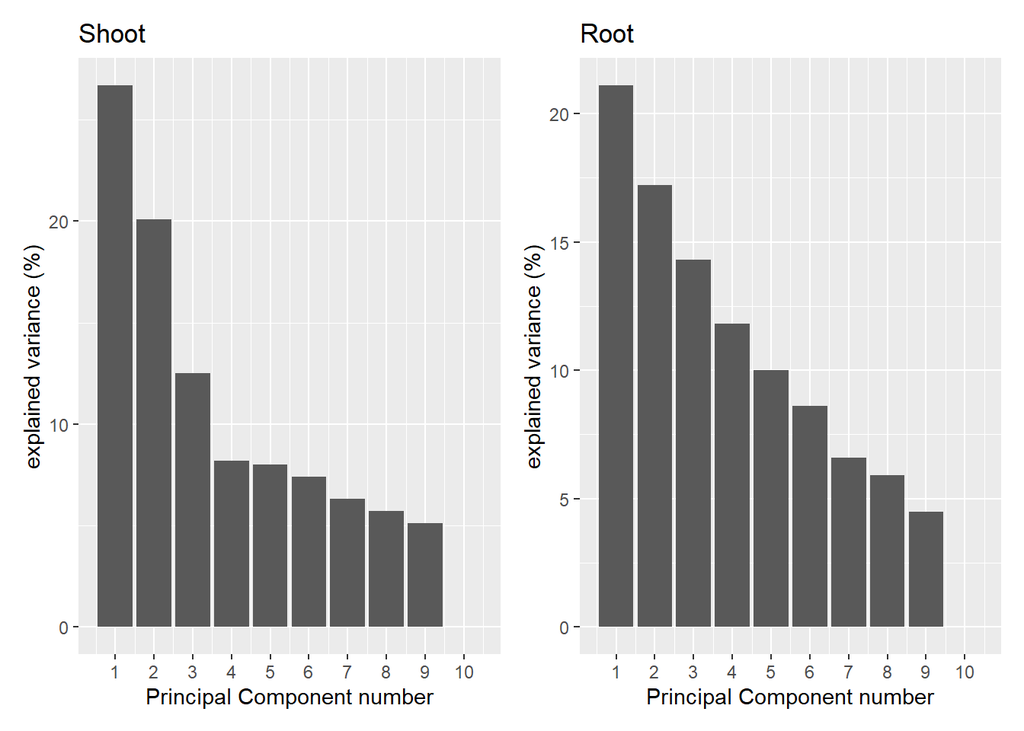

```r
p1 <- plot_scree(comp = "shoot") + ggtitle("Shoot")
p2 <- plot_scree(comp = "root") + ggtitle("Root")
p1 + p2
```

##PLS-DA analysis

We can try to see if supervised clustering analysis gives us better results. We will use PLS-DA and the package mixOmics. First find the optimal number of components with the performance check from mixOmics:

```r
source("Sly1/scripts/perf_plsda.R")
do_plsda_perf(plantpart = c("root","shoot"), n = 99) #this takes some time
```

```
##         max.dist
## overall        2
## BER            2
```

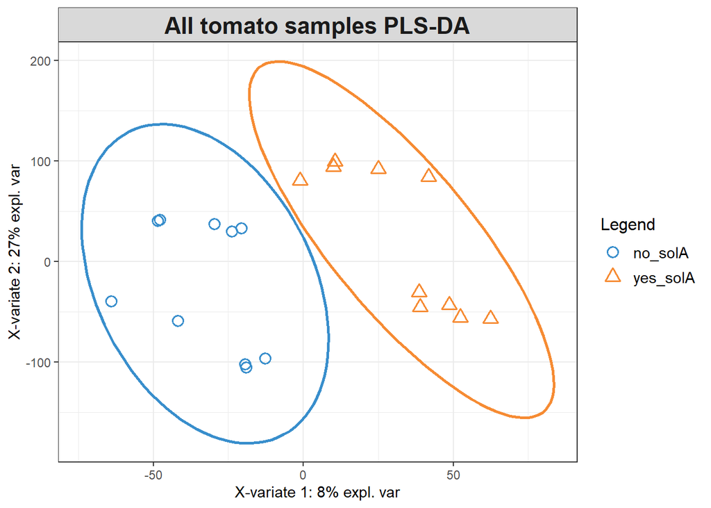

[output not shown]

[output cut: 234 more lines]

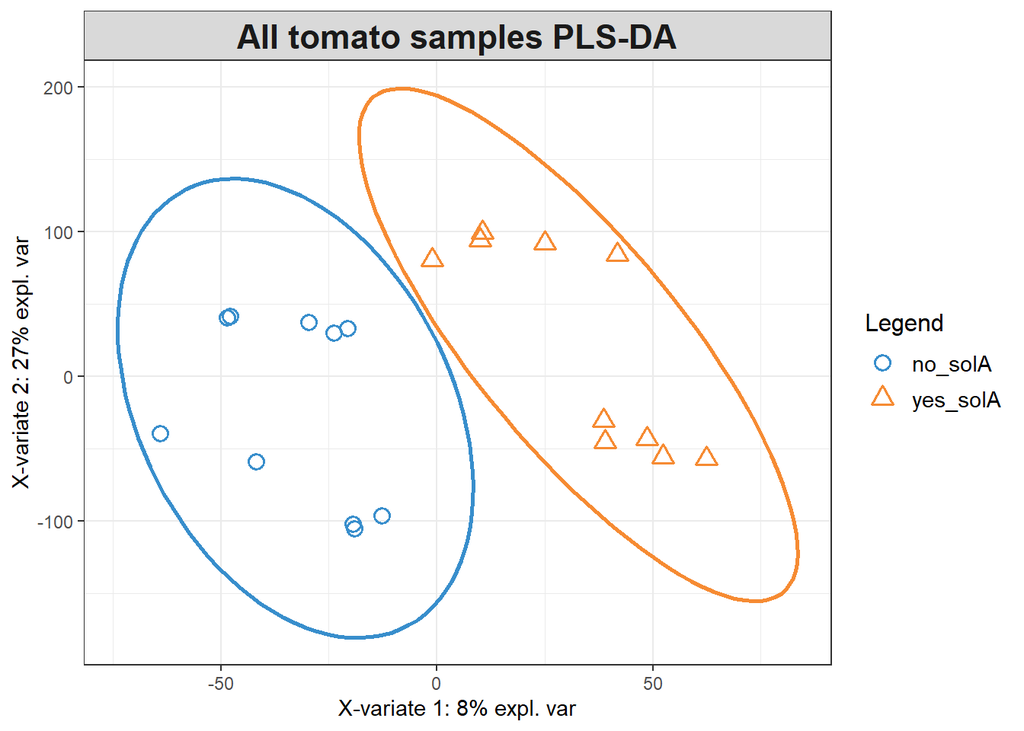

```r
source("Sly1/scripts/plsda.R")
do_plsda(plantpart = c("root","shoot"), nc = 2, ttl = "All tomato samples PLS-DA")
```

This separation is much better.

But within compartments we might find more clear results.

```r
do_plsda_perf(plantpart = "shoot", n = 99)
```

```
##         max.dist
## overall        2
## BER            2
```

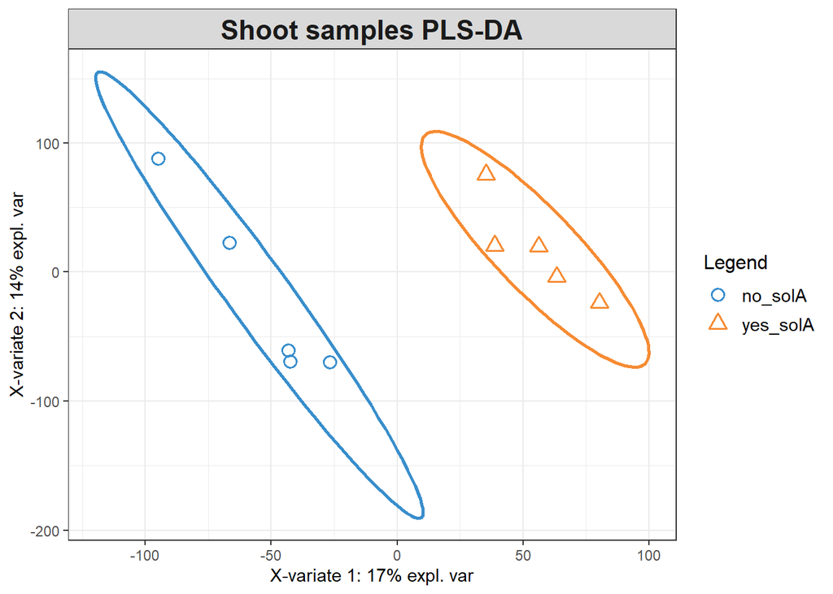

[output not shown]

[output cut: 214 more lines]

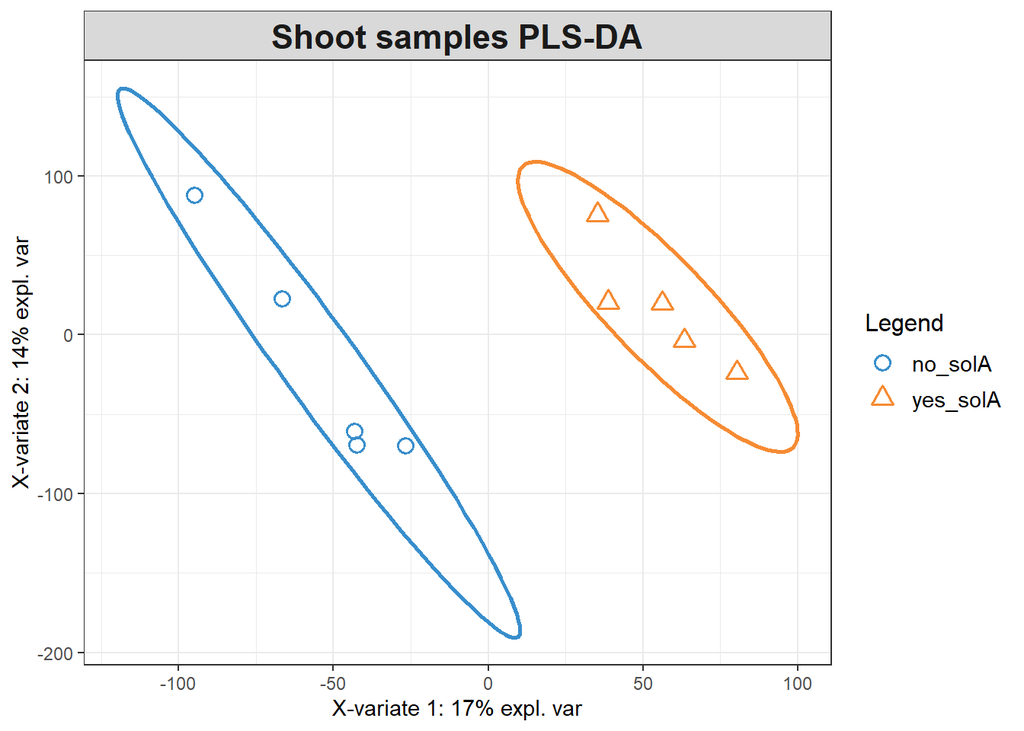

```r
do_plsda(plantpart = "shoot", nc = 2, ttl = "Shoot samples PLS-DA")
```

```r
do_plsda_perf(plantpart = "root", n = 99)
```

```
##         max.dist
## overall        2
## BER            2
```

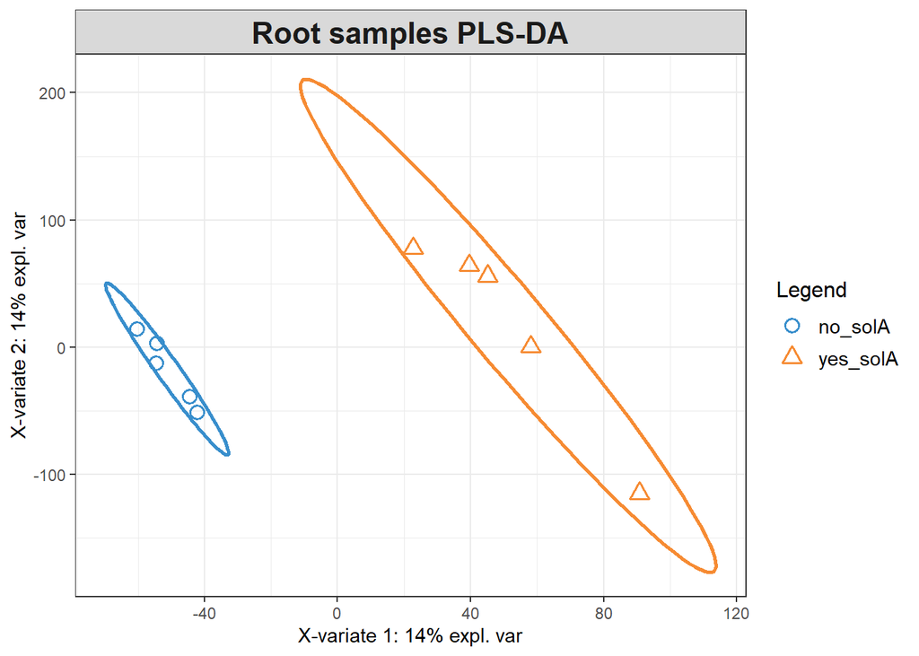

[output not shown]

[output cut: 214 more lines]

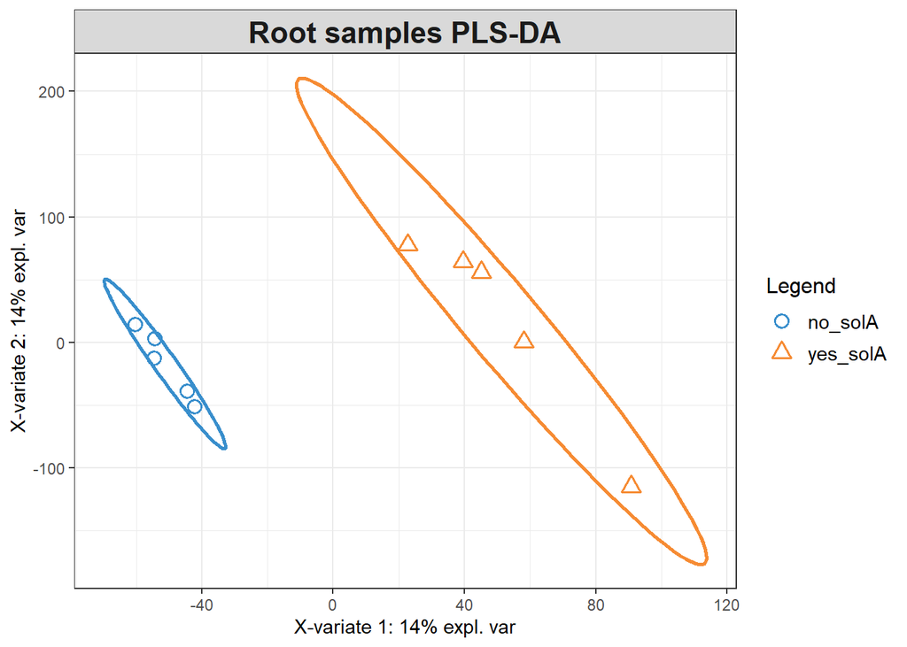

```r
do_plsda(plantpart = "root", nc = 4, ttl = "Root samples PLS-DA")
```

#DEG analysis

## Wald test

Use design formula ~ compartment + treatment

```r
source("Sly1/scripts/volcanoplot.R")
```

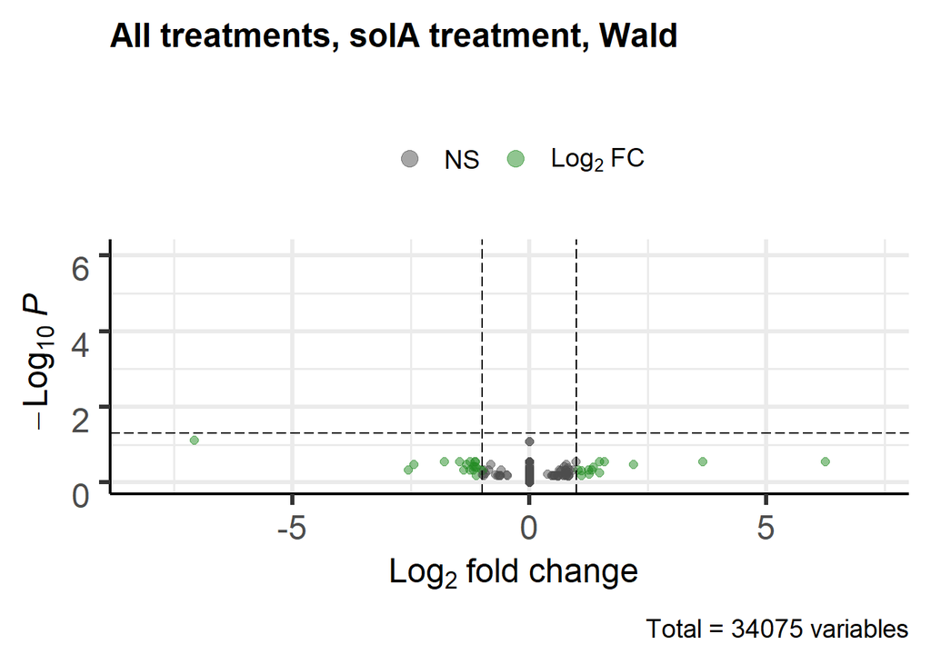

```r
make_volcanoplot(plantpart = c("root","shoot"), log2FC_threshold = 0, FCcutoff_volcano = 1, padj_threshold = 0.05, ttl = "All treatments, solA treatment, Wald", method = "compartment+treatment")
```

Again, it makes more sense to look within compartments.

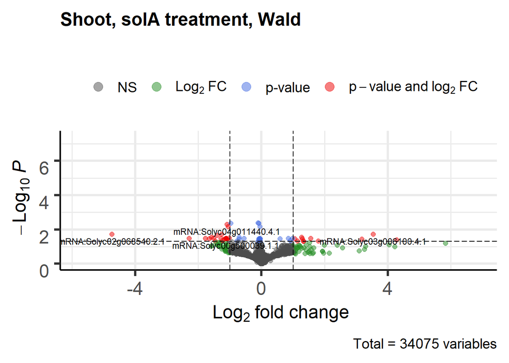

```r
make_volcanoplot(plantpart = c("shoot"), log2FC_threshold = 0, FCcutoff_volcano = 1, padj_threshold = 0.05, ttl = "Shoot, solA treatment, Wald", method = "treatment")
```

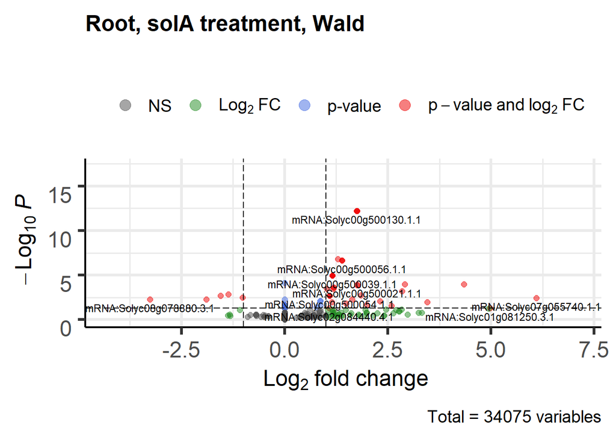

```r
make_volcanoplot(plantpart = c("root"), log2FC_threshold = 0, FCcutoff_volcano = 1, padj_threshold = 0.05, ttl = "Root, solA treatment, Wald", method = "treatment")
```

Indeed, there are several DEGs in both compartments.

##Heatmaps

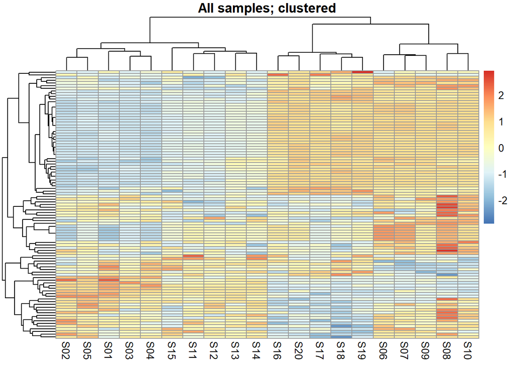

```r
source("Sly1/scripts/get_filtered_list_of_DEGs.R")
xs <- get_list_of_DEGs(plantpart = "shoot", method = "treatment", log2FC_threshold = 0)
xs <- xs %>% rownames_to_column("genes")
xr <- get_list_of_DEGs(plantpart = "root", method = "treatment", log2FC_threshold = 0)
xr <- xr %>% rownames_to_column("genes")
x <- rbind(xs, xr)
source("Sly1/scripts/produce_scaled_counts_matrix.R")
y <- produce_scaled_counts_matrix() %>% column_to_rownames("sample") %>% t() %>% as.data.frame() %>% rownames_to_column("genes")
DEG_counts <- left_join(x, y, by="genes")
DEG_counts <- DEG_counts[, -c(2,3,4,5,6,7)]
DEG_counts <- DEG_counts[!duplicated(DEG_counts$genes),]
row.names(DEG_counts) <- NULL
DEG_counts <- DEG_counts %>% column_to_rownames("genes")
xp_design <- xp_design %>% column_to_rownames("sample")

pheatmap(DEG_counts,
         gaps_col = c(5,10,15),
         cluster_rows = TRUE,
         cluster_cols = TRUE,
         show_rownames = FALSE,
         show_colnames = TRUE,
         scale = "row",
         main = "All samples; clustered")
```

In this heatmap, samples from the same treatment cluster together, which is good. Also, samples from the same compartment cluster together. There is more differences visible between samples the shoot than between samples of root, which is expected since shoot resulted in more DEGs. Let’s look more into the root samples and see whether they cluster together based on only their DEGs.

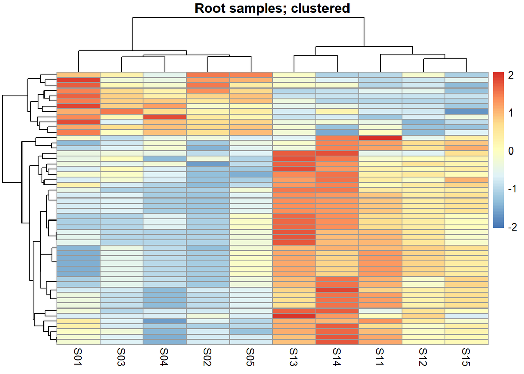

```r
x <- get_list_of_DEGs(plantpart = "root", method = "treatment", log2FC_threshold = 0)
x <- x %>% rownames_to_column("genes")

y <- filter_counts_based_on_compartment(comprtmt = "root") %>% t() %>% as.data.frame() %>% rownames_to_column("genes")
DEG_counts <- left_join(x, y, by="genes")
DEG_counts <- DEG_counts[, -c(2,3,4,5,6,7)]
DEG_counts <- DEG_counts[!duplicated(DEG_counts$genes),]
DEG_counts <- DEG_counts %>% column_to_rownames("genes")
xp_design <- xp_design %>% column_to_rownames("sample")

pheatmap(DEG_counts,
         gaps_col = 5,
         cluster_rows = TRUE,
         cluster_cols = TRUE,
         show_rownames = FALSE,
         show_colnames = TRUE,
         scale = "row",
         main = "Root samples; clustered")
```

Indeed the samples from the same treatment cluster together.

## LRT

Compare Wald test with LRT test, which checks the null-model with the full model. First for the complete tomato dataset.

```r
source("Sly1/scripts/compare_Wald_vs_LRT.R")
compare_wald_vs_LRT(compartment = c("root","shoot"), method = "compartment+treatment")
```

```
## found already estimated dispersions, replacing these
```

```
## [1] "LRT gives 0 DEGs, while Wald test gives 0 DEGs."
```

```
## # A tibble: 0 x 7
## # ... with 7 variables: gene <chr>, baseMean <dbl>, log2FoldChange <dbl>,
## #   lfcSE <dbl>, stat <dbl>, pvalue <dbl>, padj <dbl>
```

This is a confirmation that there are no overlapping DEGs betwen compartments induced by solA treatment. Check also the within compartment comparisons:

```r
compare_wald_vs_LRT(compartment = "root", method = "treatment")
```

```
## found already estimated dispersions, replacing these
```

```
## [1] "LRT gives 47 DEGs, while Wald test gives 52 DEGs."
```

```
## # A tibble: 47 x 7
##    gene                  baseMean log2FoldChange lfcSE  stat   pvalue       padj
##    <chr>                    <dbl>          <dbl> <dbl> <dbl>    <dbl>      <dbl>
##  1 mRNA:Solyc00g500021.~     108.          1.90  0.355  5.35 8.62e- 8    1.19e-4
##  2 mRNA:Solyc00g500024.~    1855.          0.978 0.224  4.36 1.28e- 5    8.08e-3
##  3 mRNA:Solyc00g500039.~   11225.          1.23  0.212  5.81 6.21e- 9    1.12e-5
##  4 mRNA:Solyc00g500044.~   11105.          1.24  0.212  5.82 5.83e- 9    1.12e-5
##  5 mRNA:Solyc00g500054.~     577.          1.22  0.258  4.72 2.41e- 6    1.95e-3
##  6 mRNA:Solyc00g500055.~    1119.          1.29  0.248  5.20 1.97e- 7    2.30e-4
##  7 mRNA:Solyc00g500056.~    2102.          1.47  0.226  6.50 7.95e-11    2.33e-7
##  8 mRNA:Solyc00g500068.~     108.          1.90  0.357  5.33 1.00e- 7    1.31e-4
##  9 mRNA:Solyc00g500071.~    1853.          0.982 0.224  4.38 1.16e- 5    7.56e-3
## 10 mRNA:Solyc00g500083.~   11225.          1.23  0.212  5.81 6.21e- 9    1.12e-5
## # ... with 37 more rows
```

```r
compare_wald_vs_LRT(compartment = "shoot", method = "treatment")
```

```
## found already estimated dispersions, replacing these
```

```
## [1] "LRT gives 37 DEGs, while Wald test gives 53 DEGs."
```

```
## # A tibble: 37 x 7
##    gene                    baseMean log2FoldChange lfcSE  stat    pvalue   padj
##    <chr>                      <dbl>          <dbl> <dbl> <dbl>     <dbl>  <dbl>
##  1 mRNA:Solyc00g500039.1.1 20750.            -1.29 0.313 -4.14 0.0000349 0.0334
##  2 mRNA:Solyc00g500044.1.1 20534.            -1.29 0.312 -4.14 0.0000345 0.0334
##  3 mRNA:Solyc00g500083.1.1 20750.            -1.29 0.313 -4.14 0.0000350 0.0334
##  4 mRNA:Solyc00g500301.1.1 20537.            -1.29 0.312 -4.14 0.0000349 0.0334
##  5 mRNA:Solyc00g500325.1.1 20535.            -1.29 0.312 -4.14 0.0000345 0.0334
##  6 mRNA:Solyc01g066770.3.1     7.56          -5.41 1.34  -4.04 0.0000540 0.0346
##  7 mRNA:Solyc01g081540.4.1   223.            -1.29 0.321 -4.01 0.0000616 0.0350
##  8 mRNA:Solyc01g074000.3.1   229.             1.44 0.333  4.32 0.0000159 0.0275
##  9 mRNA:Solyc01g150150.1.1     8.54          -5.59 1.37  -4.09 0.0000433 0.0335
## 10 mRNA:Solyc02g065610.3.1   203.            -1.48 0.360 -4.11 0.0000392 0.0335
## # ... with 27 more rows
```

#Annotation of DEGs

To infer the function of solA on tomato, we have to infer the function of the DEGs. Since looking at the complete dataset hardly gives us DEGs, we only look at yes/no solA within the compartments.

```r
source("Sly1/scripts/get_annotated_DEGs.R")
gg <- get_annotated_DEGs(plantpart = "root", method = "treatment")
```

```
## Import genomic features from the file as a GRanges object ... OK
## Prepare the 'metadata' data frame ... OK
## Make the TxDb object ... OK
## Starting BioMart query ...
```